# Exploratory Correlation Analysis of Redox Related Metabolites in Erlotinib-treated Head and Neck Cancer Patients

# Data collected on each patient

- Erlotinib, OSI-420 (oxidated form of erlotinib), and ratio of the two
- Erlotinib dose (smoker 300, non-smoker 150)
- Free, bound, and total cholesterol before and after erlotinib treatment
- Various oxisterols before and after erlotinib treatment
- Cysteine and GSH redox couples before and after erlotinib treatment
- Tumor decrease in response to the treatment
- Free, bound, and total cholesterol before and after erlotinib treatment in buccal swab samples

# erlotinib vs tumor response

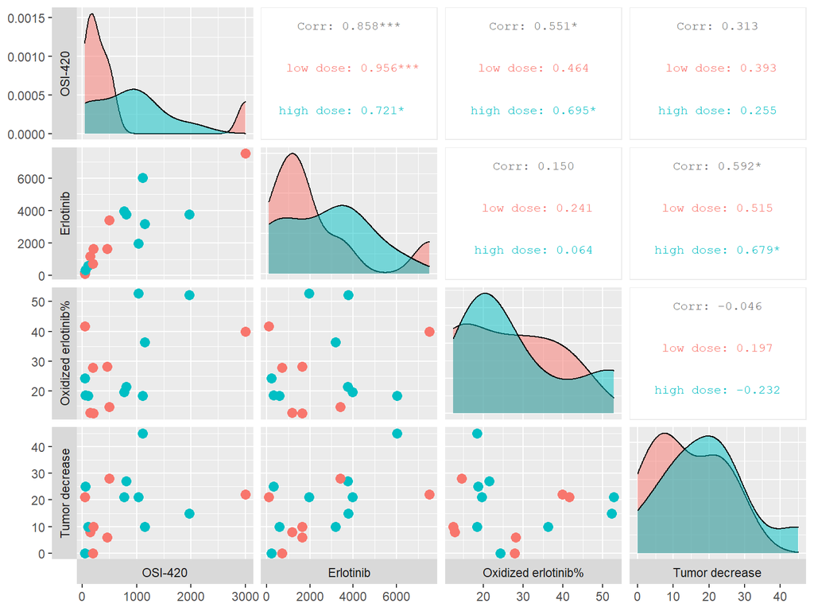

- Tumor decrease is bigger in the high dose group (panel 4.4) and correlates positively with erlotinib (panel 2.4).

# erlotinib vs tumor response

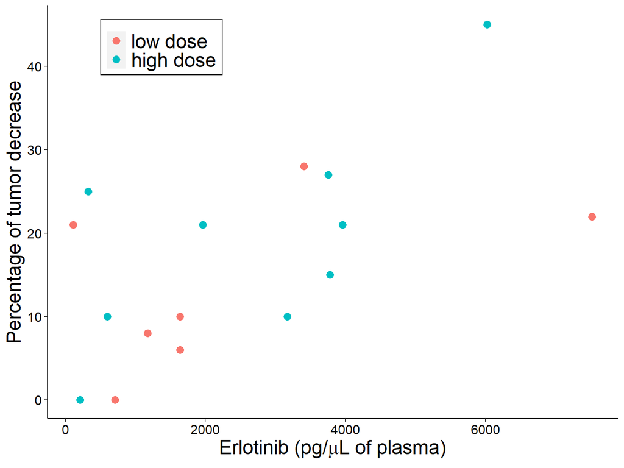

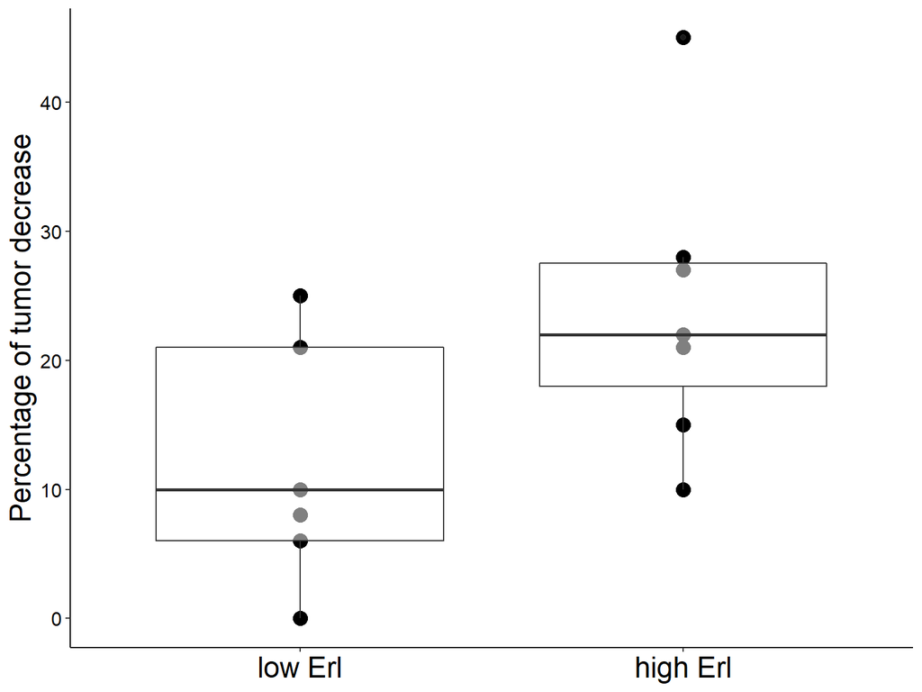

(left) Since tumor response correlates with erlotinib, single out erlotinib vs tumor pair to plot. The correlation coefficient is 0.592, with 0.679 for the high dose group and 0.515 for the low dose group.

(right) Discretize erlotinib concentration into two categories (less or greater than 2000). It is clear that the tumor decrease is higher in the high erlotinib group. p-value = 0.032 by t-test, p-value = 0.025 by Mann-Whitney U test.

# cholesterol (before) vs tumor response

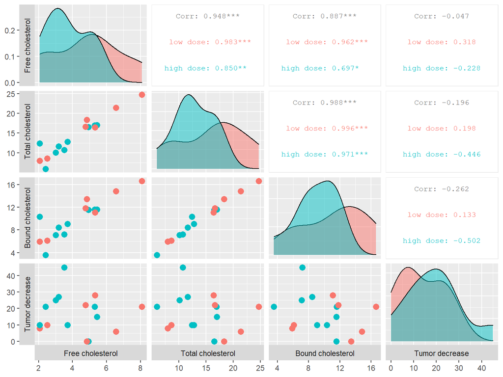

- Tumor decrease negatively correlates with bound and total cholesterol in patients receiving high dose treatment (panel 2.4, 3.4): maybe related to smoking? This is before treatment, certainly has nothing to do with erlotinib dose.

# cholesterol (after) vs tumor response

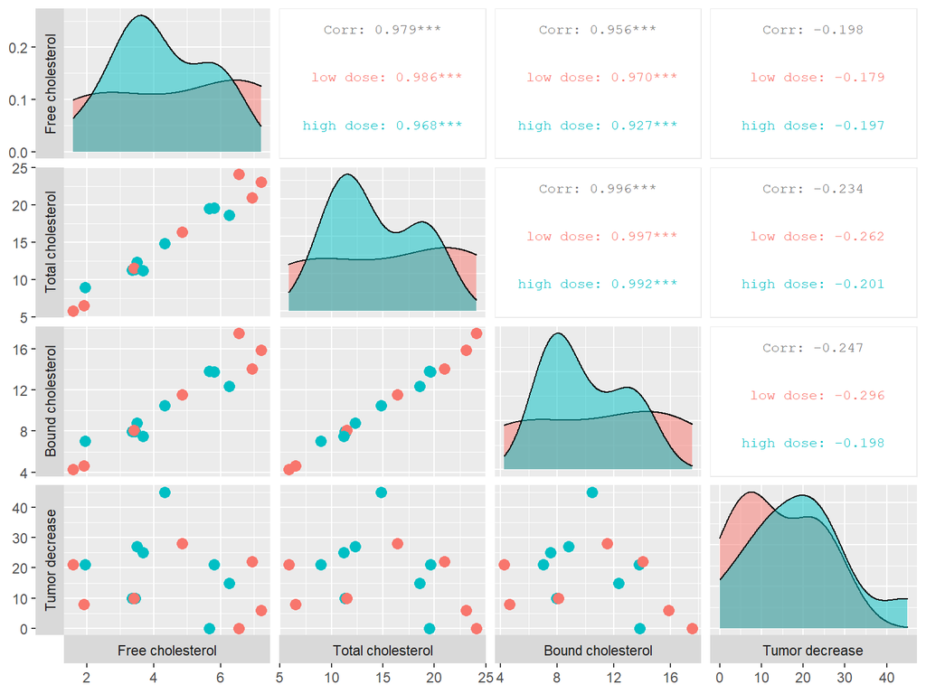

- The effect described in previous page is absent after treatment.

# oxysterols (before) vs tumor response

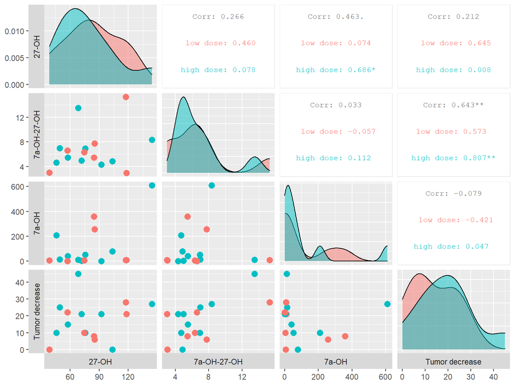

- 7a-OH-27-OH is a really good indicator of tumor response (panel 2.4), so is 27-OH in low dose patients (non-smoker)(panel 1.4).

# oxysterols (after) vs tumor response

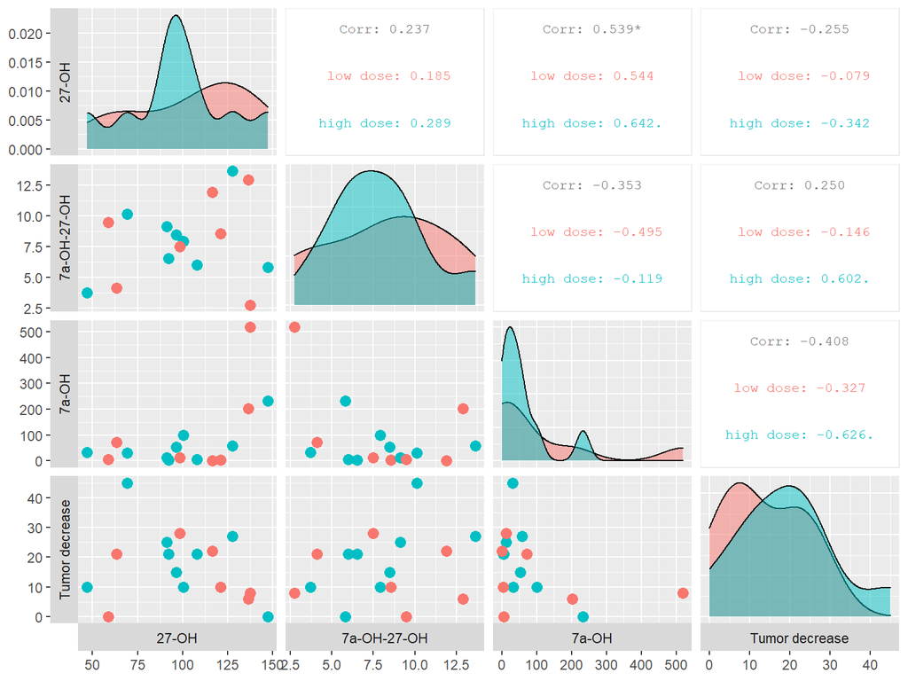

# redox pairs (before) vs tumor response

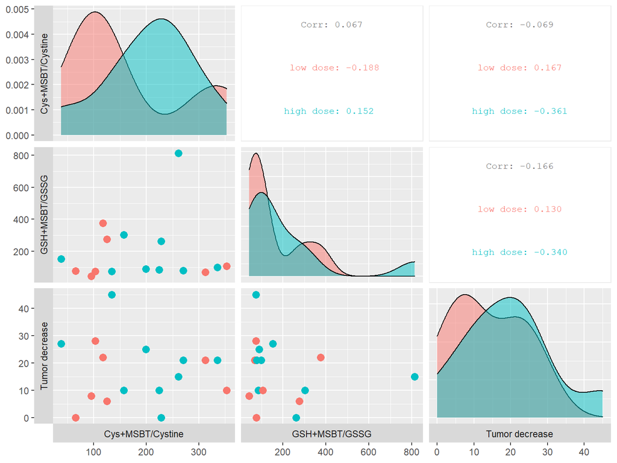

- Smokers have higher Cys+MSBT/Cystine ratio (panel 1.1).

# redox pairs (after) vs tumor response

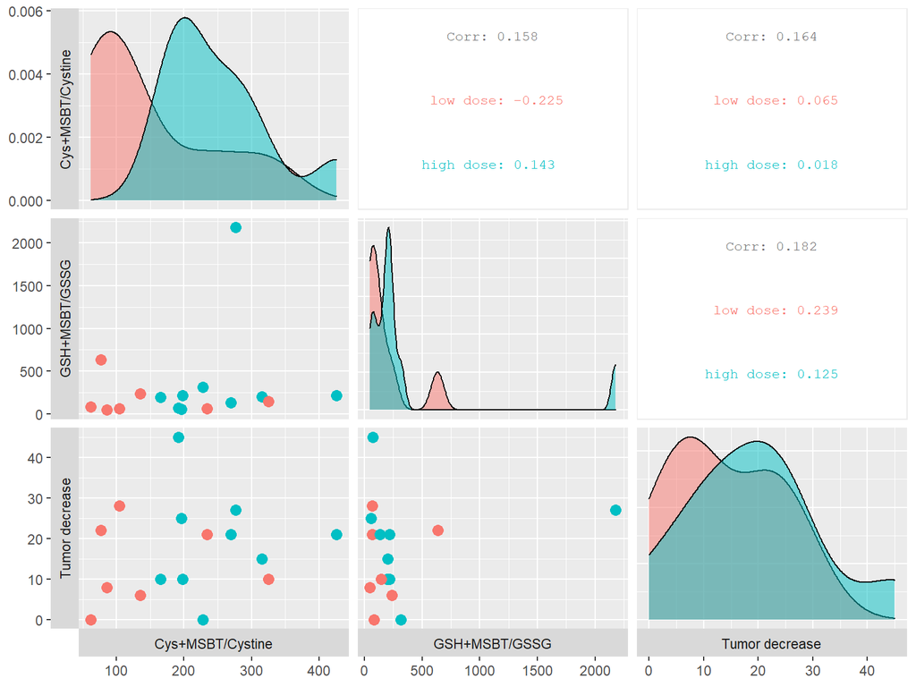

- After the treatment, smokers still have higher Cys+MSBT/Cystine ratio (panel 1.1).

# redox pairs (before) vs tumor response, low GSSG points removed

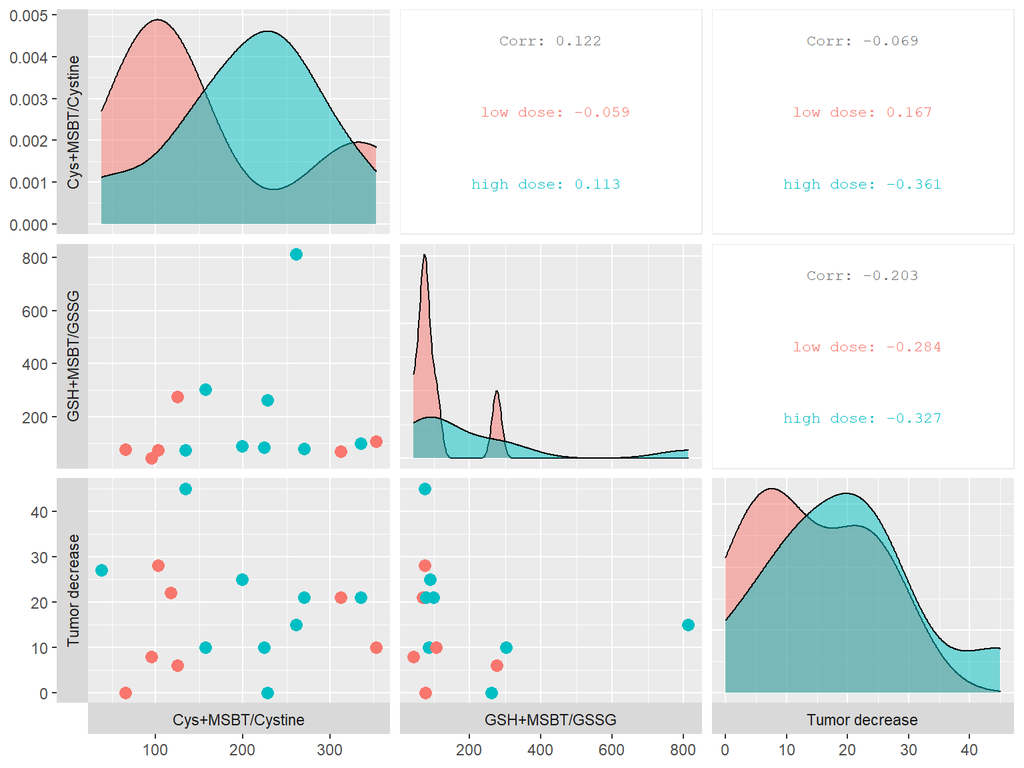

- Removed a few really low GSSG data points.

# redox pairs (after) vs tumor response, low GSSG points removed

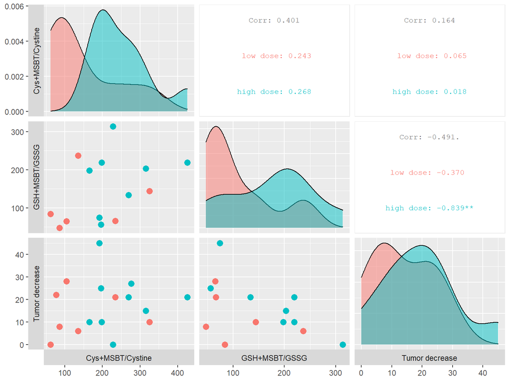

- Tumor response is inversely correlated with GSH+MSBT/GSSG ratio post-treatment especially in the high erlotinib dose subgroup (panel 2.3).

# Cys redox vs erlotinib dose (smoking)

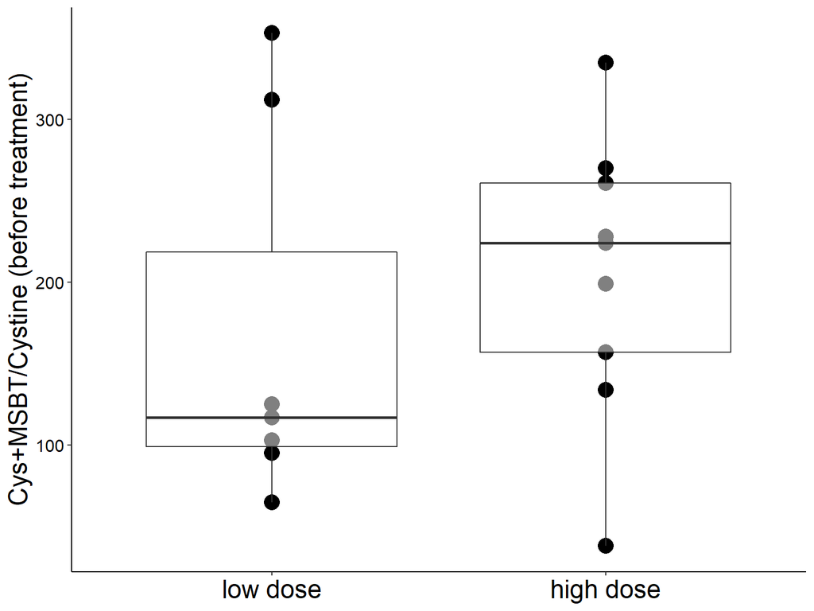

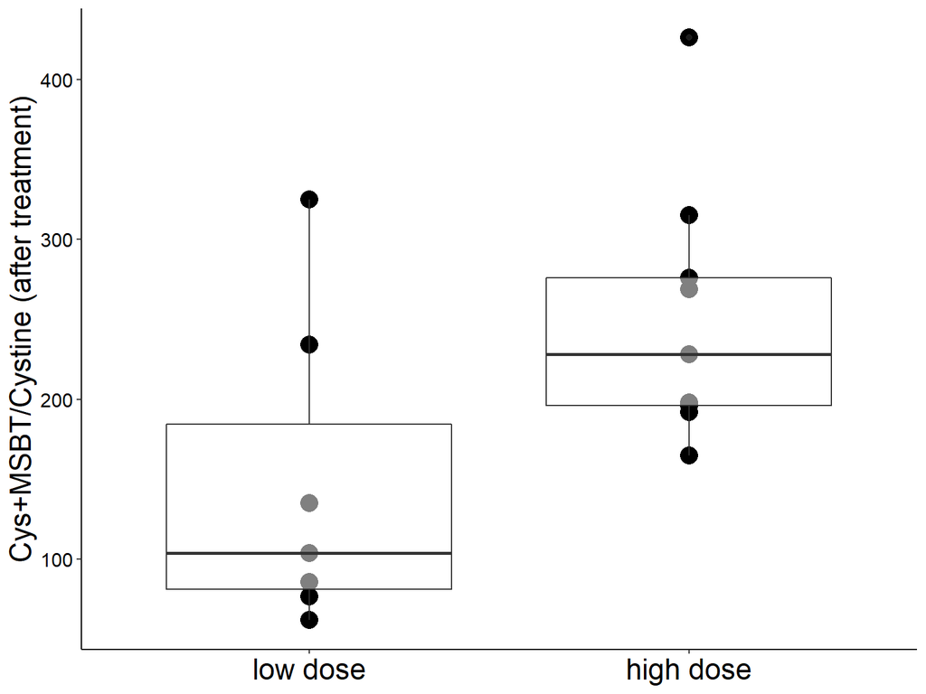

- High dose patients (smokers) have higher reduced to oxidized cysteine ratio pre- and post- treatment. (left, before treatment) p-value = 0.483 by t-test, p-value = 0.351 by Mann-Whitney U test. (right, after treatment) p-value = 0.04 by t-test, p-value = 0.055 by Mann-Whitney U test.

# Buccal cholesterol (before) vs tumor response

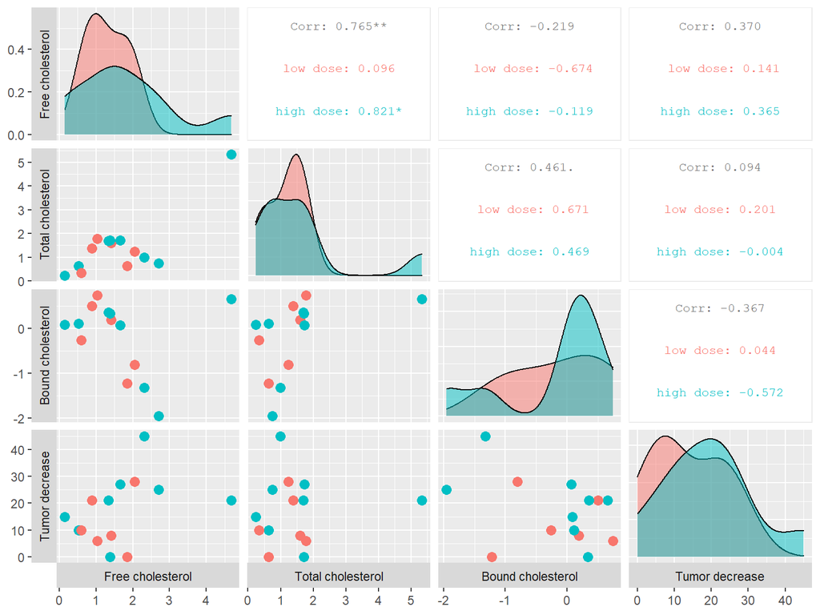

# Buccal cholesterol (after) vs tumor response

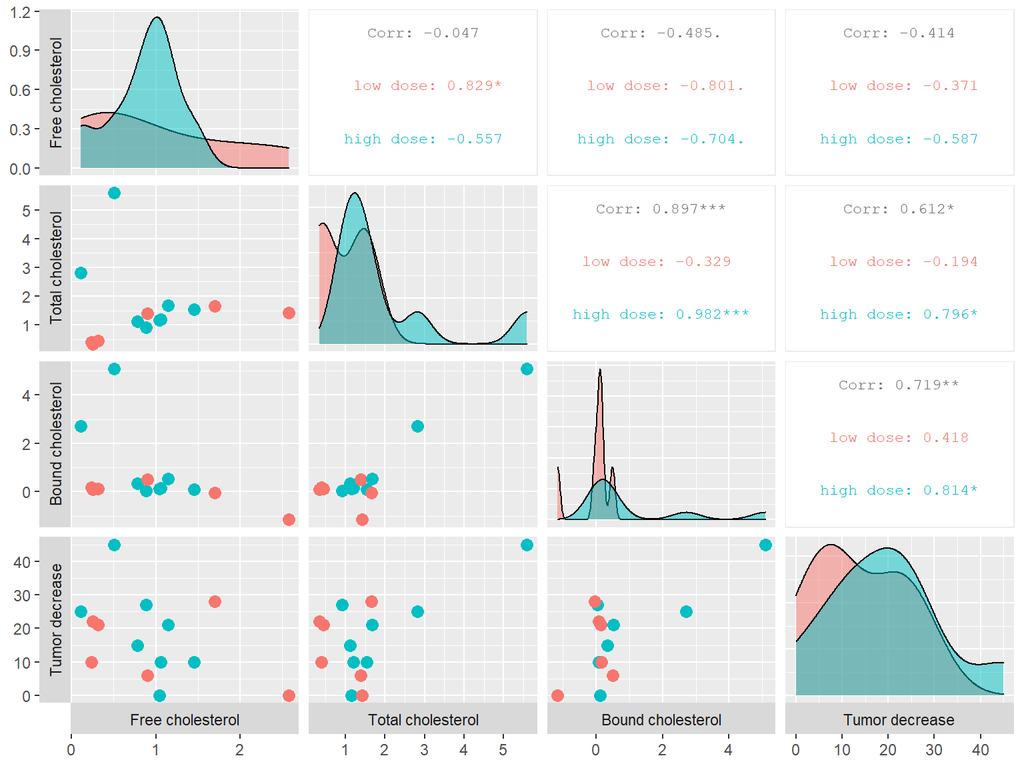

- Total and bound cholesterol in post-treatment buccal swab samples correlates with tumor decrease especially in the high erlotinib dose group (panel 2.4, 3.4). Keep in mind that bound cholesterol has some negative values (from total - free), so the accuracy of measurement is questionable.

# plasma cholesterol before and after treatment

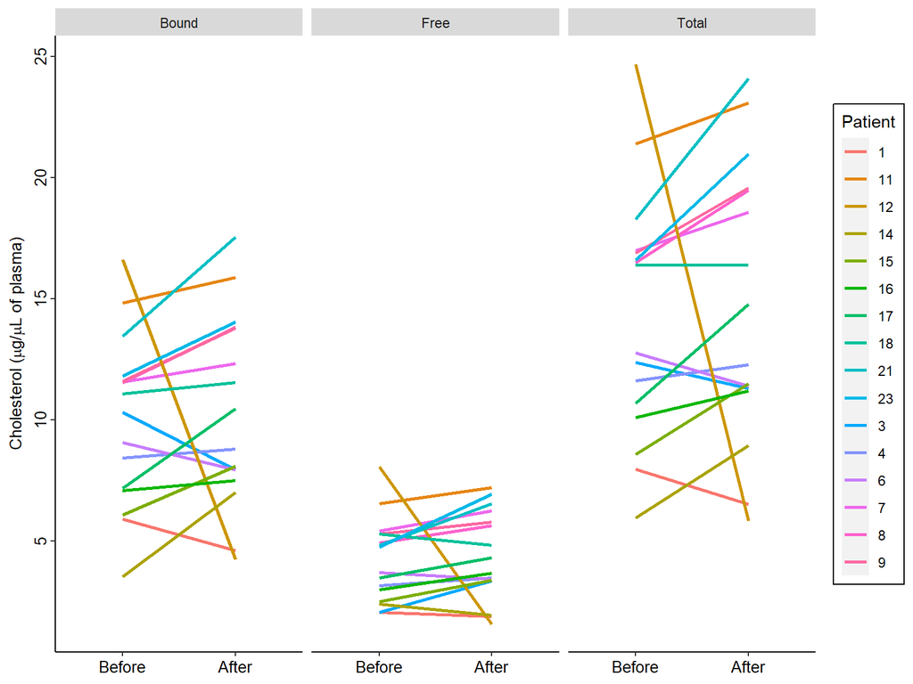

- Interestingly, plasma cholesterol seems to be increased in most patients after treatment.

# Multiple linear regression - single predictor

For model selection, here we use the forward selection with adjusted R^2 method. We choose single predictors from the plasma samples before the treatment.

- erlotinib adjusted R^2 = 0.3043168
- total cholesterol adjusted R^2 = -0.030099
- 7a-OH-27-OH adjusted R^2 = 0.3716456
- GSH-MSBT/GSSG ratio adjusted R^2 = -0.0385081

So first we pick 7a-OH-27-OH.

# Multiple linear regression - adding second predictor

- 7a-OH-27-OH + erlotinib adjusted R^2 = 0.436523
- 7a-OH-27-OH + total cholesterol adjusted R^2 = 0.3323755
- 7a-OH-27-OH + GSH-MSBT/GSSG ratio adjusted R^2 = 0.3295507

So we go with 7a-OH-27-OH + erlotinib.

# Multiple linear regression - adding third predictor

- 7a-OH-27-OH + erlotinib + total cholesterol adjusted R^2 = 0.3929037
- 7a-OH-27-OH + erlotinib + GSH-MSBT/GSSG ratio adjusted R^2 = 0.460375

So we go with 7a-OH-27-OH + erlotinib + GSH-MSBT/GSSG ratio.

# Multiple linear regression - final model

- 7a-OH-27-OH + erlotinib + GSH-MSBT/GSSG ratio + total cholesterol adjusted R^2 = 0.4192897
- adding total cholesterol doesn’t help

```
##
## Call:
## lm(formula = TumorDecrease ~ Oxy7aOH27OHB + Erlotinib + GSHRtoOBnew,
##     data = data)
##
## Residuals:
##    Min     1Q Median     3Q    Max
## -9.249 -5.748 -2.322  6.074 13.891
##
## Coefficients:
##               Estimate Std. Error t value Pr(>|t|)
## (Intercept)   5.243856   5.890358   0.890   0.3942
## Oxy7aOH27OHB  0.899904   0.949574   0.948   0.3656
## Erlotinib     0.003768   0.001968   1.915   0.0845 .
## GSHRtoOBnew  -0.018357   0.013283  -1.382   0.1971
## ---
## Signif. codes:  0 '***' 0.001 '**' 0.01 '*' 0.05 '.' 0.1 ' ' 1
##
## Residual standard error: 8.939 on 10 degrees of freedom
##   (2 observations deleted due to missingness)
## Multiple R-squared:  0.5849, Adjusted R-squared:  0.4604
## F-statistic: 4.697 on 3 and 10 DF,  p-value: 0.02696
```